# Assignment Week 5

### Name: Yizhen Dai

### ULCN: S2395479

### Exercise 1

We will use the EM algorithm to estimate the parameters of a normal mixture model and study its behavior. Recall that $X$ follows a normal mixture distribution if it has density,
$$f(x; \theta) = \sum_{k = 1}^K w_k \phi(x; \mu_k, \sigma_k),$$
where

- $\theta = (w_1, \dots, w_K, \mu_1, \sigma_1, \dots, \mu_K, \sigma_K)$ is the vector of unknown parameters,
- $\phi(\cdot; \mu, \sigma)$ is the density of a $\mathcal{N}(\mu, \sigma^2)$ random variable.

Also keep in mind that there are constraints on the parameters:

- $\sum_{k = 1}^K w_k = 1$
- $\sigma_k > 0, 0 \le w_k \le 1$ for all $k = 1, \dots, K$.

**(a)** Write a function `rmixt()` that simulates from a Gaussian mixture model. The function should take four arguments:

- `n`: the number of samples to simulate,
- `w`, `mu`, `sigma`: the model parameters (length `K` vectors).

Verify that your function is correct by making a histogram of simulated data. This function will be useful to check whether your solution of (c) is correct.

**Solution**

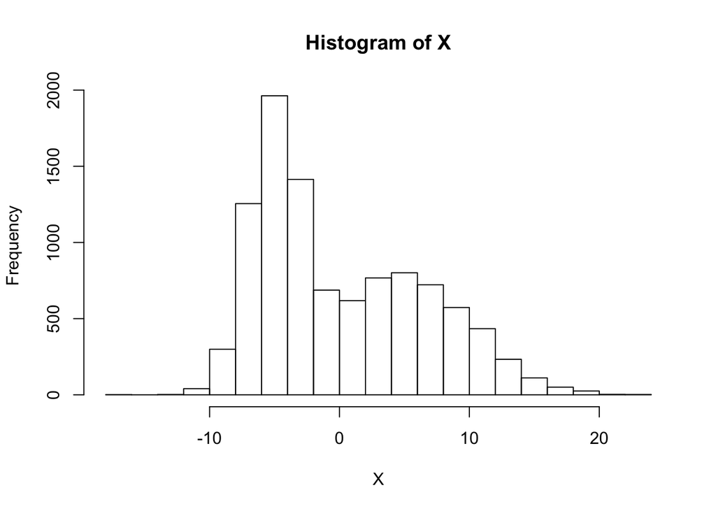

```r
rmixt <- function(n, w, mu, sigma) {
  k <- sample(1:length(w), n, replace = TRUE, prob = w)
  rnorm(n, mean = mu[k], sd = sigma[k])
}

X <- rmixt(10^4, c(0.5,0.5), c(-5,5), c(2,5))
hist(X)
```

**(b)** Write a function `dmixt()` that computes the mixture density. It should take the following arguments:

- `x`: vector of evaluation points,
- `w`, `mu`, `sigma`: the model parameters (length `K` vectors).

Verify that your function is correct by plotting the density over a histogram of simulated data.

**Solution**

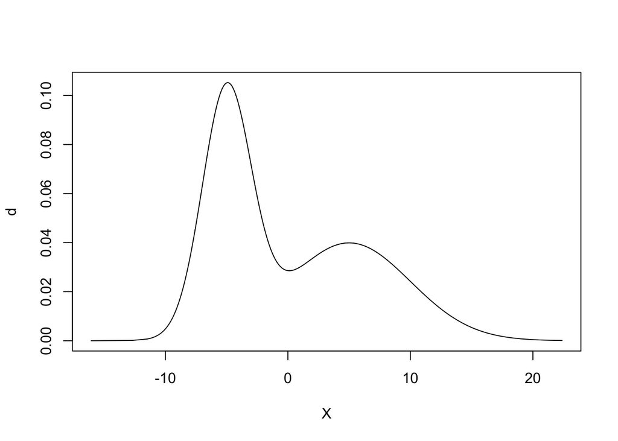

```r
dmixt <- function(x, w, mu, sigma) {
  sapply(x, FUN=function(x_) sum(w * dnorm(x_, mu, sigma)))
}

X <- sort(X)
d <- dmixt(X, c(0.5,0.5), c(-5,5), c(2,5))
plot(X, d, type = 'l')
```

**(c)** Write a function `fit_em()` that implements the EM algorithm for fitting the Gaussian mixture parameters. The function should take five arguments

- `x`: the data,
- `w, mu, sigma`: initial guesses for parameters.
- `eps`: a threshold value that is used to terminate the algorithm as soon as the parameters reach their optimal values.

It should return a matrix with columns `(w, mu, sigma)`.

**Solution**

$w_{k}^{(t+1)}=\frac{\sum_{i=1}^{n} \pi_{k, i}}{\sum_{y=1}^{K} \sum_{i=1}^{n} \pi_{k, i}}$

$\mu_{k}^{(t+1)}=\frac{\sum_{i=1}^{n} X_{i} \pi_{k, i}}{\sum_{i=1}^{n} \pi_{k, i}}, \quad \sigma_{k}^{(t+1)}=\sqrt{\frac{\sum_{i=1}^{n}\left(X_{i}-\mu_{k}^{(t+1)}\right)^{2} \pi_{k, i}}{\sum_{i=1}^{n} \pi_{k, i}}}$

```r
fit_em <- function(x, w, mu, sigma, eps) {

  if_pass <- 0 # check if meet converging criteria
  i <- 0       # counter
  while(!if_pass){
    sum_pie <- sapply(1:length(w),   # sum pi for i from 1 to n
       FUN=function(k) sum(w[k]*dnorm(x, mu[k], sigma[k])/dmixt(x, w, mu, sigma)))
    w_new <- sum_pie/sum(sum_pie)

    sum_Xpie <- sapply(1:length(w),
       FUN=function(k) sum(x*w[k]*dnorm(x, mu[k], sigma[k])/dmixt(x, w, mu, sigma)))
    mu_new <- sum_Xpie/sum_pie

    sum_MSEpie <- sapply(1:length(w),
       FUN=function(k) sum((x-mu[k])^2*w[k]*dnorm(x, mu[k], sigma[k])/dmixt(x, w, mu, sigma)))
    sigma_new <- sqrt(sum_MSEpie/sum_pie)

    if_pass <- prod((w_new - w) < eps)*
               prod((mu_new - mu) < eps)*
               prod((sigma_new - sigma) < eps)

    i <- i + 1
    w <- w_new
    mu <- mu_new
    sigma <- sigma_new
  }
  cat('A total of ',i,' iterations.\n')
  return(list('w' = w, 'mu' = mu, 'sigma' = sigma))
}

results <- fit_em(X, c(0.4,0.6), c(-4,6), c(2,4), 10^-3)
```

```
## A total of  37  iterations.
```

```r
results
```

```
## $w
## [1] 0.4872062 0.5127938
##
## $mu
## [1] -4.993151  5.006971
##
## $sigma
## [1] 1.996689 5.055998
```

**(d)**

We will now investigate the role of the starting parameters. We will use the following data:

```r
set.seed(5)
w_true <- c(0.2, 0.3, 0.5)
mu_true <- c(0.5, 2, 4)
sigma_true <- c(0.5, 1, 0.5)
X <- rmixt(1000, w_true, mu_true, sigma_true)
```

Consider the following choices of initial guesses:

1. `w <- w_true; mu <- mu_true; sigma <- sigma_true`.
2. `w <- rep(1/3, 3); mu <- rep(mean(X), 3); sigma <- rep(sd(X), 3)`
3. `w <- rep(1/3, 3); mu <- mean(X) + sd(X) * c(-1, 0, 1); sigma <- rep(sd(X), 3)`
4. The group frequency/mean/SD where groups are computed via the k-means algorithm:

```r
clusters <- kmeans(X, 3)$cluster
w <- table(clusters) / length(X)
mu <- tapply(X, clusters, mean)
sigma <- tapply(X, clusters, sd)
```

For every choice of starting parameters, run the EM algorithm and compare the estimated densities with a histogram. Which methods can you recommend for practical use?

**Solution**

```r
### sort X
X <- sort(X)
```

##### 1.

```r
w <- w_true; mu <- mu_true; sigma <- sigma_true

results <- fit_em(X, w, mu, sigma, 10^-3)
```

```
## A total of  65  iterations.
```

```r
print(results)
```

```
## $w
## [1] 0.2299268 0.2634065 0.5066667
##
## $mu
## [1] 0.5472599 2.1765953 4.0104474
##
## $sigma
## [1] 0.5489271 0.9139057 0.5041564
```

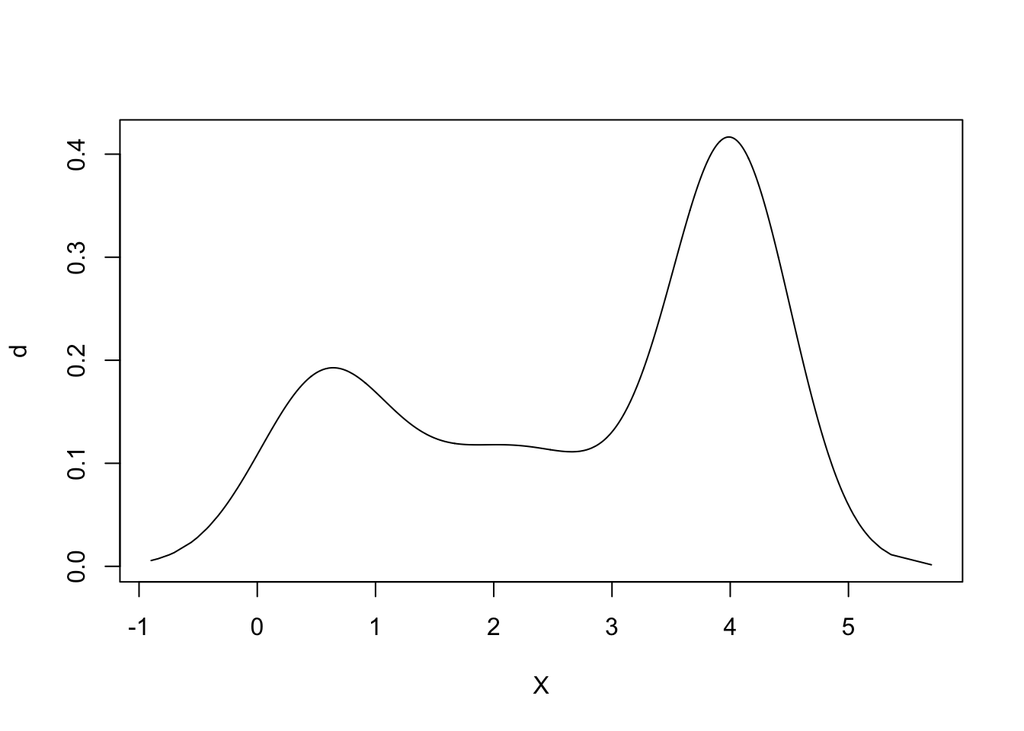

```r
d <- dmixt(X, results$w, results$mu, results$sigma)
plot(X, d, type = 'l')
```

##### 2.

```r
w <- rep(1/3, 3); mu <- rep(mean(X), 3); sigma <- rep(sd(X), 3)

results <- fit_em(X, w, mu, sigma, 10^-3)
```

```
## A total of  1  iterations.
```

```r
print(results)
```

```
## $w
## [1] 0.3333333 0.3333333 0.3333333
##
## $mu
## [1] 2.731119 2.731119 2.731119
##
## $sigma
## [1] 1.557206 1.557206 1.557206
```

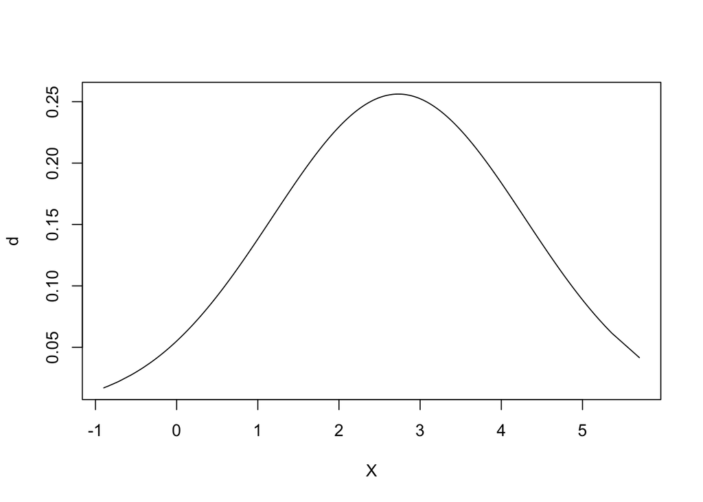

```r
d <- dmixt(X, results$w, results$mu, results$sigma)
plot(X, d, type = 'l')
```

##### 3.

```r
w <- rep(1/3, 3); mu <- mean(X) + sd(X) * c(-1, 0, 1); sigma <- rep(sd(X), 3)

results <- fit_em(X, w, mu, sigma, 10^-3)
```

```
## A total of  27  iterations.
```

```r
print(results)
```

```
## $w
## [1] 0.2671177 0.2718156 0.4610667
##
## $mu
## [1] 0.6377167 2.5712888 4.0381515
##
## $sigma
## [1] 0.5982402 0.9718470 0.4826091
```

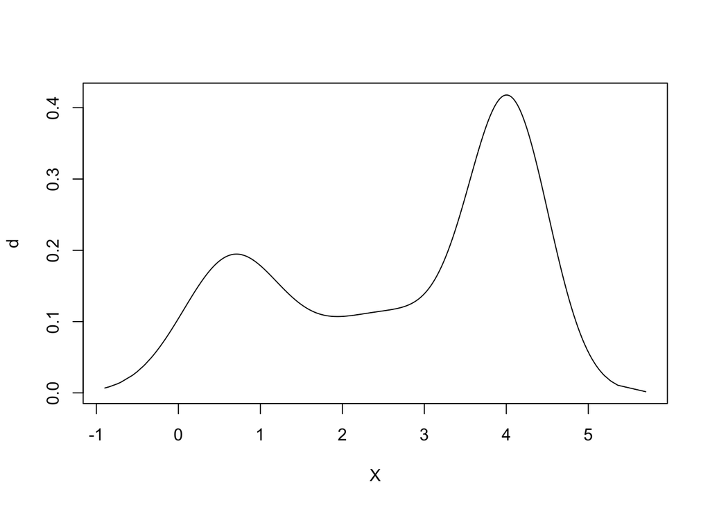

```r
d <- dmixt(X, results$w, results$mu, results$sigma)
plot(X, d, type = 'l')
```

##### 4.

```r
clusters <- kmeans(X, 3)$cluster
w <- table(clusters) / length(X)
mu <- tapply(X, clusters, mean)
sigma <- tapply(X, clusters, sd)

results <- fit_em(X, w, mu, sigma, 10^-3)
```

```
## A total of  8  iterations.
```

```r
print(results)
```

```
## $w
## [1] 0.1775791 0.5377119 0.2847091
##
## $mu
## [1] 2.2828348 3.9851446 0.6423255
##
## $sigma
## [1] 0.5902742 0.5146977 0.5839654
```

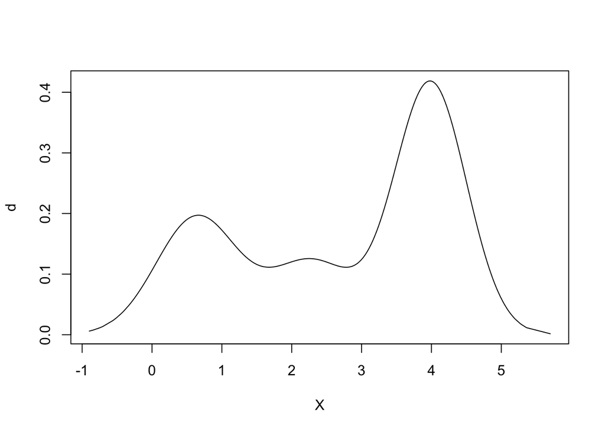

```r
d <- dmixt(X, results$w, results$mu, results$sigma)
plot(X, d, type = 'l')
```

I would recommend the last method. - The first method is not realistic. - The second method is not correct since it does not update - The third method is slow to converge and does not show three peaks - The last method converges pretty quickly and show the correct peaks

## Exercise 2

Consider the following data:

```r
set.seed(5)
X <- rexp(500)
Y <- 2 + 0.5 * X + rnorm(500)
dat <- data.frame(Y, X)
```

We fit a linear model to this data and compute confidence intervals for both parameters:

```r
fit <- lm(Y ~ X, data = dat)
confint(fit)
```

```
##                 2.5 %    97.5 %
## (Intercept) 1.8057234 2.0463849
## X           0.4971383 0.6585376
```

Now implement a bootstrap algorithm to estimate 95%-confidence intervals for both parameters. Compare your results to the confidence intervals above.

**Solution:** We will use empirical bootstrap to compute beta’s and Normal boostrap to construct confident intervals (based on the normality assumption of linear models)

```r
#### Empirical bootstrap algorithm
B <- 1000
set.seed(1000)

M1 <- model.matrix(fit)

beta_stars <- t(sapply(1:B, function(b){
  y <- fit$fitted  + sample(residuals(fit), replace = TRUE) # empirical
  bstar <- coefficients(lm(y ~ M1 - 1, data = dat))
  return(t(bstar))
  }))

### construct the confident intervals
se_boot <- apply(beta_stars, 2, sd) # Bootstrap se's of the coefficients
results <- rep(fit$coefficients, 2) + # estimate of the coefficients
  rep(se_boot,2) * qnorm(c(0.025, 0.025, 0.975, 0.975))
names(results) <- c('int_low', 'beta_low', 'int_high', 'beta_high')

results
```

```
##   int_low  beta_low  int_high beta_high
## 1.8066593 0.4967432 2.0454491 0.6589327
```

We can the bootstrap results are very close the calculated ones.